# Text Analysis

Lab 2

## Expanded Functions of Topic Models

Topic models can be extended to include covariates. If we add a variable to the prevalence argument, we are examining how another variable might predict the probability of a topic occuring within a document.

```r
library(dplyr)

library(stm)

library(stringr)

library(tm)

library(textstem)

load("C:/Users/sberry5/Documents/teaching/courses/unstructured/data/allLyricsDF.RData")

load("C:/Users/sberry5/Documents/teaching/courses/unstructured/data/countryTop50.RData")

allTop50 = allTop50 %>%
  group_by(song) %>%
  slice(1)

hardRemove = c(34, 78, 91, 94, 107, 136, 150, 202, 210, 213, 222, 229, 232,
               239, 245, 248, 268, 276, 277, 284, 285, 291, 309, 310, 356,
               403, 419, 424, 425, 460, 467, 482, 490, 497, 519, 532, 545,
               555, 585, 586, 616, 639, 642, 648, 653, 654, 658, 682, 704,
               705, 719, 722, 760, 780, 794, 795, 802, 832, 836, 851, 867,
               872, 878, 891, 921, 924, 931, 944, 972, 985, 995, 1026, 1029,
               1032, 1041, 1042, 1063, 1101, 1102, 1111, 1115, 1121, 1124,
               1126, 1128, 1144, 1145, 1158, 1166, 1172, 1175, 1186, 1202,
               1204, 1209, 1211, 1215, 1218, 1225, 1240, 1251, 1256, 1257,
               1272, 1287, 1311, 1316, 1326, 1327, 1342, 1361, 1421, 1462,
               1493, 1534, 1584, 1609, 1627, 1629, 1635, 1638, 1649, 1667,
               1676, 1679, 1690, 1696, 1707, 1710, 1717, 1720, 1755, 1758,
               1760, 1780, 1786, 1788, 1798, 1805, 1847, 1855, 1858, 1861,
               1866, 1882, 1895, 1918, 1929, 1946, 1952, 1994, 2000, 2011,
               2017, 2018, 2019, 2027, 2032, 2039, 2055, 2069, 2143, 2164,
               2193, 2200, 2201, 2204, 2246, 2254, 2285, 2303, 2318, 2334,
               2347, 2373, 2383, 2395, 2397, 2401, 2402, 2406, 2434, 2443,
               2459, 2469, 2472, 2475, 2499, 2507, 2527, 2534, 2540, 2563,
               2564, 2566, 2570, 2572, 2597, 2604, 2632, 2638, 2655, 2661,
               2666, 2685, 2696, 2719, 2721, 2724, 2729, 2736, 2740, 2754,
               2764, 2767, 2768, 2771, 2803, 2843, 2877, 2903, 2905, 2913,
               2944, 2951, 2969, 2972, 2978, 2995, 3016, 3041, 3043, 3048, 3092)

cleanLyrics = allLyricsDF[-c(hardRemove)] %>%
  filter(warningIndicator == 0) %>%
  dplyr::select(lyrics, returnedArtistName, returnedSong) %>%
  mutate(text = as.character(lyrics),
         text = str_replace_all(text, "\n", " "),
         text = str_replace_all(text, "(\\[.*?\\])", ""),
         text = str_squish(text),
         text = gsub("([a-z])([A-Z])", "\\1 \\2", text),
         text = tolower(text),
         text = removeWords(text, c("’", stopwords(kind = "en"))),
         text = removePunctuation(text),
         text = removeNumbers(text),
         text = lemmatize_strings(text),
         doc_id = returnedSong,
         author = returnedArtistName) %>%
  select(doc_id, text, author)

cleanLyrics = left_join(cleanLyrics, allTop50, by = c("doc_id" = "song"))

# To make things easier on the model side, we can just drop our NAs for now.

load("C:/Users/sberry5/Documents/teaching/courses/unstructured/data/countryTop50.RData")

cleanLyrics = na.omit(cleanLyrics)

cleanLyrics = cleanLyrics %>%
  mutate(year = lubridate::year(date))

lyricText = textProcessor(documents = cleanLyrics$text,
                          metadata = cleanLyrics,
                          stem = FALSE)
```

```
Building corpus...
Converting to Lower Case...
Removing punctuation...
Removing stopwords...
Removing numbers...
Creating Output...
```

```r
lyricPrep = prepDocuments(documents = lyricText$documents,
                               vocab = lyricText$vocab,
                               meta = lyricText$meta)
```

```
Removing 3371 of 6975 terms (3371 of 101475 tokens) due to frequency
Your corpus now has 1718 documents, 3604 terms and 98104 tokens.
```

```r
set.seed(1001)

topicPredictor = stm(documents = lyricPrep$documents,
             vocab = lyricPrep$vocab, prevalence = ~ year,
             data = lyricPrep$meta, K = 5, verbose = FALSE, seed = 1001)

# If significant, overdispersion is a problem and more topics might be needed!

checkResiduals(topicPredictor, documents = lyricPrep$documents)
```

```
$dispersion
[1] 4.378803

$pvalue
[1] 0

$df
[1] 1740716
```

```r
labelTopics(topicPredictor)
```

```
Topic 1 Top Words:
     Highest Prob: little, get, night, drink, dance, just, want
     FREX: drink, ready, momma, bite, jean, neon, rock
     Lift: crashin, eden, fireball, laredo, marilyn, myrtle, pier
     Score: passionate, little, drink, rock, burn, saturday, dance
Topic 2 Top Words:
     Highest Prob: like, back, see, old, time, just, away
     FREX: angel, fly, wind, rain, sail, mountain, wing
     Lift: atlanta, cherish, cloudless, cnn, demon, disagree, fragile
     Score: wing, angel, holy, rain, flirtin, fall, southern
Topic 3 Top Words:
     Highest Prob: baby, get, gonna, like, girl, yes, aint
     FREX: baby, wanna, gonna, gotta, ooh, somebodys, tonight
     Lift: balcony, barfly, couldnt, emotional, flavor, honeysuckle, huggin
     Score: baby, tonkin, wanna, gonna, gotta, girl, honey
Topic 4 Top Words:
     Highest Prob: good, get, aint, man, boy, country, say
     FREX: tonk, blah, honky, gimme, bye, aaron, hillbilly
     Lift: arizona, backroad, banjo, basketball, bid, bikini, blah
     Score: mercury, country, tonk, honky, blah, gimme, bye
Topic 5 Top Words:
     Highest Prob: love, know, say, just, heart, never, time
     FREX: someone, heart, true, touch, fool, goodbye, love
     Lift: adrift, chisel, command, conscience, content, cope, curve
     Score: love, heart, someone, stranger, lonely, darling, lie
```

Let’s look at the correlations between topics:

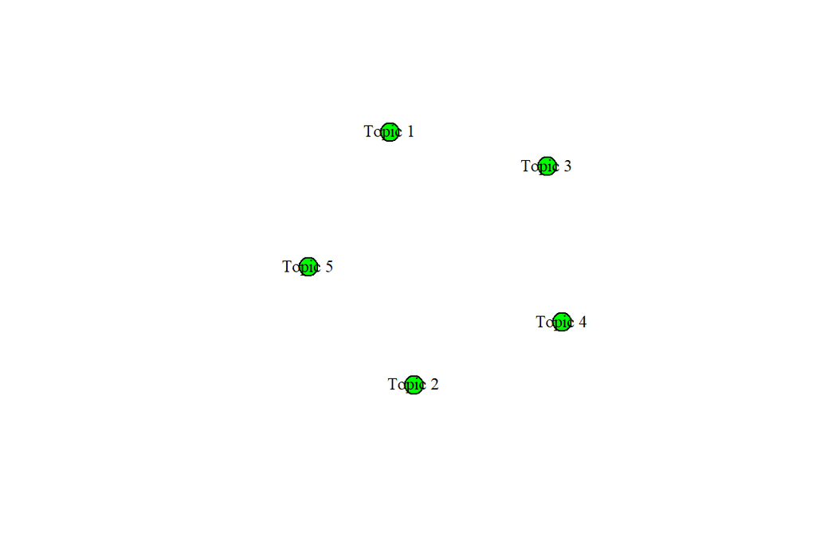

```r
plot.topicCorr(topicCorr(topicPredictor))
```

Not terribly surprising.

With our new model, we can actually test the effect of year on topic.

```r
set.seed(1001)

yearEffect = estimateEffect(1:5 ~ year, stmobj = topicPredictor,
               metadata = lyricPrep$meta)

summary(yearEffect, topics = c(1:5))
```

```
Call:
estimateEffect(formula = 1:5 ~ year, stmobj = topicPredictor,
    metadata = lyricPrep$meta)


Topic 1:

Coefficients:
              Estimate Std. Error t value Pr(>|t|)
(Intercept) -7.7537985  0.7911891  -9.800   <2e-16 ***
year         0.0039523  0.0003967   9.963   <2e-16 ***
---
Signif. codes:  0 '***' 0.001 '**' 0.01 '*' 0.05 '.' 0.1 ' ' 1


Topic 2:

Coefficients:
              Estimate Std. Error t value Pr(>|t|)
(Intercept) -0.1140568  0.9060418  -0.126    0.900
year         0.0001412  0.0004542   0.311    0.756


Topic 3:

Coefficients:
              Estimate Std. Error t value Pr(>|t|)
(Intercept) -7.9979905  0.8605497  -9.294   <2e-16 ***
year         0.0040939  0.0004314   9.490   <2e-16 ***
---
Signif. codes:  0 '***' 0.001 '**' 0.01 '*' 0.05 '.' 0.1 ' ' 1


Topic 4:

Coefficients:
              Estimate Std. Error t value Pr(>|t|)
(Intercept) -1.8569788  1.0132271  -1.833    0.067 .
year         0.0010005  0.0005079   1.970    0.049 *
---
Signif. codes:  0 '***' 0.001 '**' 0.01 '*' 0.05 '.' 0.1 ' ' 1


Topic 5:

Coefficients:
              Estimate Std. Error t value Pr(>|t|)
(Intercept) 18.7138324  1.2025806   15.56   <2e-16 ***
year        -0.0091835  0.0006029  -15.23   <2e-16 ***
---
Signif. codes:  0 '***' 0.001 '**' 0.01 '*' 0.05 '.' 0.1 ' ' 1
```

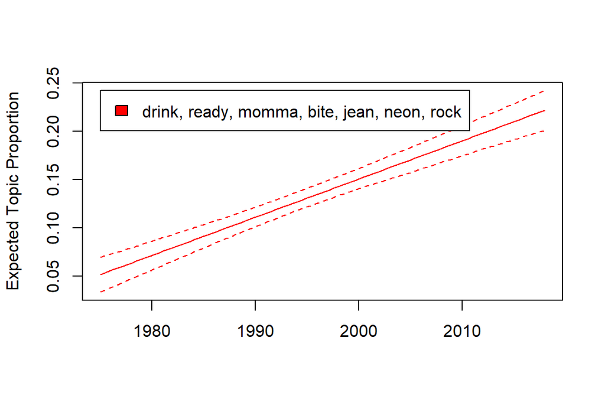

```r
plot.estimateEffect(yearEffect, "year", method = "continuous",
                    model = topicPredictor, topics = 1, labeltype = "frex")
```

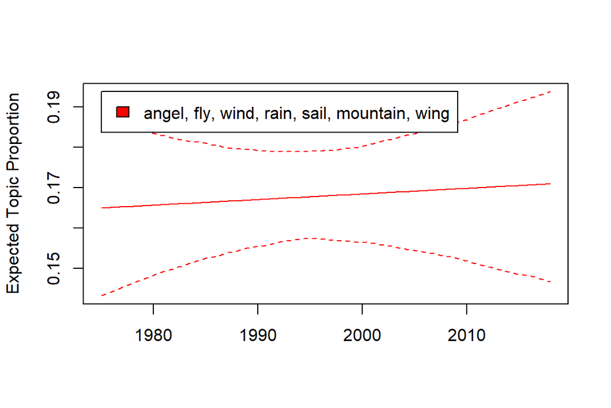

```r
plot.estimateEffect(yearEffect, "year", method = "continuous",
                    model = topicPredictor, topics = 2, labeltype = "frex")
```

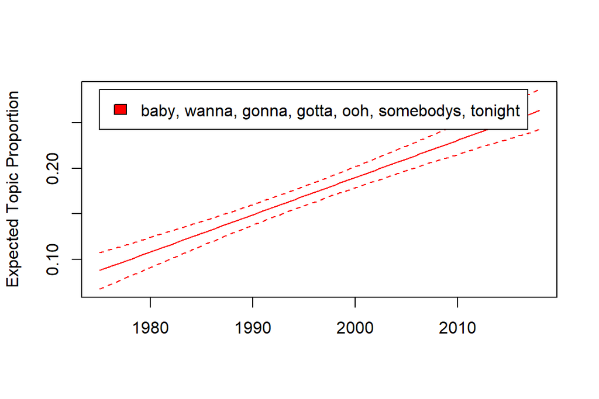

```r
plot.estimateEffect(yearEffect, "year", method = "continuous",
                    model = topicPredictor, topics = 3, labeltype = "frex")
```

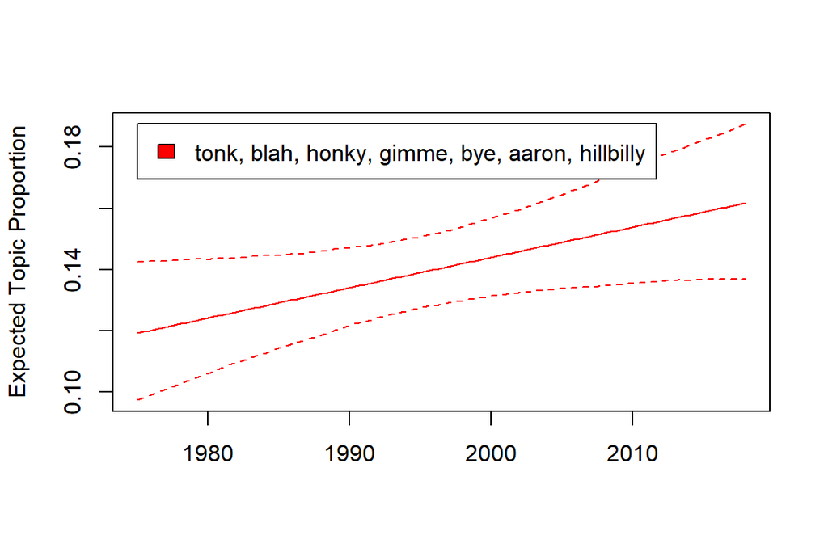

```r
plot.estimateEffect(yearEffect, "year", method = "continuous",
                    model = topicPredictor, topics = 4, labeltype = "frex")
```

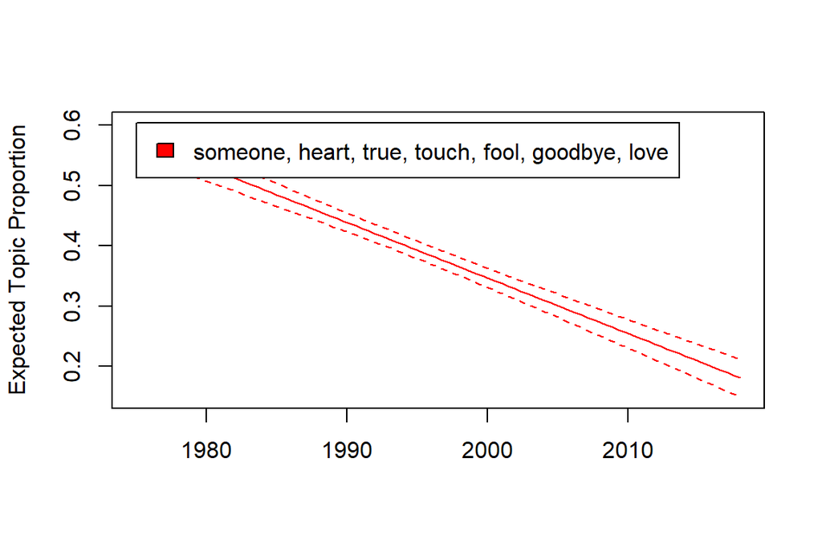

```r
plot.estimateEffect(yearEffect, "year", method = "continuous",
                    model = topicPredictor, topics = 5, labeltype = "frex")
```

We can add additional information to our models: content. What we get here is a better understanding about how people use language within a topic differently.

It should be noted that this will be a completely different model than what we had before. For these content-based models, we are saying that there is some difference between our content covariate with how words are used in topics, so our model will try to find the base words and then which words are used for the different levels of our content.

```r
topicContent = stm(documents = lyricPrep$documents,
             vocab = lyricPrep$vocab, content = ~ year,
             data = lyricPrep$meta, K = 5, verbose = FALSE, seed = 1001)
```

```r
labelTopics(topicContent)
```

```
Topic Words:
 Topic 1: pearly, want, sweatshirt, study, unfurl, dodge, lamp
 Topic 2: coffee, watch, face, across, stare, job, frighten
 Topic 3: honey, baby, love, town, diva, dawn, call
 Topic 4: weekend, definitely, chitown, bumper, dog, smokies, jersey
 Topic 5: strong, heart, never, stay, part, always, without

 Covariate Words:
 Group 1975: partys, hearted, jennings, nelson, hog, rubber, pig
 Group 1976: funny, factory, trap, small, guy, straighten, cab
 Group 1977: cafe, tune, flower, silver, prove, tremble, exactly
 Group 1978: readin, train, onenight, ramblin, speakin, hollywood, smart
 Group 1979: sweetheart, paper, lock, fumble, must, jim, paris
 Group 1980: oclock, six, deal, wash, buddy, gin, cowboy
 Group 1981: lovely, sex, fit, yet, opposite, everyone, horn
 Group 1982: special, sunshine, deliver, vow, often, waltz, oneway
 Group 1983: daylight, dixieland, either, hardly, marriage, bartender, anger
 Group 1984: rockin, illinois, chair, smoky, share, land, restless
 Group 1985: satisfy, jumpin, honestly, glad, pistol, desire, railroad
 Group 1986: instrumental, steel, tonights, bloom, smokin, comin, grant
 Group 1987: rumor, pillow, twinkle, owe, tend, search, texas
 Group 1988: admit, power, tree, pride, neon, speak, cuz
 Group 1989: gamble, paul, situation, lovely, larry, nelson, foolish
 Group 1990: agree, row, hometown, rule, recall, jukebox, early
 Group 1991: desire, sight, symphony, seldom, willow, stream, magazine
 Group 1992: pen, leg, lesson, oughta, motel, sunshine, deal
 Group 1993: angry, ash, ooo, neon, upon, devotion, rockies
 Group 1994: romance, forward, sayin, chain, power, simple, plant
 Group 1995: twice, tough, tornado, caution, sense, hall, takin
 Group 1996: september, horse, daddys, imagination, angel, letter, harvest
 Group 1997: fact, devotion, feelin, cream, mistake, cloud, earth
 Group 1998: month, short, shape, season, fear, mornin, overcome
 Group 1999: surround, surpass, overhear, fail, note, row, skip
 Group 2000: grant, curse, cure, couch, precious, sell, moment
 Group 2001: wrap, skin, dinner, pace, cream, sir, paintin
 Group 2002: boat, eighteen, uncle, afternoon, secondhand, rag, lunch
 Group 2003: future, chase, mexico, barefoot, early, smoke, square
 Group 2004: bubble, waitin, palm, champagne, drawer, short, stave
 Group 2005: york, grace, spot, jumpin, dare, mercy, average
 Group 2006: grain, remind, send, dad, mom, neck, pray
```

[output cut: 223 more lines]

```
 Topic 5, Group 2004: abilene, console, freeway, twostep, bell, tower, swingin
 Topic 5, Group 2005: vega, pant, raisin, gamble, freeway, unwind, patch
 Topic 5, Group 2006: tone, crook, desperate, odd, careful, stupid, fairy
 Topic 5, Group 2007: backwoods, fightin, ville, reminisce, james, serious, grain
 Topic 5, Group 2008: helpless, thirtyfive, mustang, aisle, backyard, pirate, sober
 Topic 5, Group 2009: patron, reachin, wont, type, advice, stroll, addict
 Topic 5, Group 2010: overnight, battle, sting, frame, neither, content, lack
 Topic 5, Group 2011: toast, stake, whine, christian, burst, sunrise, shimmer
 Topic 5, Group 2012: granddaddy, freak, divorce, suit, magnolia, hesitation, preach
 Topic 5, Group 2013: stripe, revenge, bathroom, neighbour, bark, rattle, generation
 Topic 5, Group 2014: woah, circle, mail, damage, knot, wreck, style
 Topic 5, Group 2015: rip, cuttin, driveway, pad, screw, harm, cheer
 Topic 5, Group 2016: peter, creepin, climbin, cigarette, plenty, ifs, nature
 Topic 5, Group 2017: reel, whatcha, yep, stealin, grade, major, college
 Topic 5, Group 2018: starin, inspiration, daze, holy, nervous, weakness, standin
```

## The Data

The data that we will be using comes from review data that some of us have already seen – spectator feedback. You will find it in the data folder (called *feedbackData.RData*) and it contains only 3 variables: the sport, the feedback, and an overall satisfaction score.

## The Objectives

As a preliminary pass through the data, you might want to conduct a regular topic model (after doing any bit of text cleaning, of course). Try various values of *k* and make a decision based upon the output of `searchK`. After making your decision, run your topic model with your decided *k* value. Explore the results of your analyses and determine if you can create a coherent story for each of the topics.

After running the regular topic model, take some time to explore if any of the additional variables might be interesting to include as a covariate.